# Unüberwachtes Lernen mit dem Herz-Datensatz

# Clustering und PCA auf die Herzdaten

## Einlesen der Herz-Daten

Es werden wieder die Herzdaten aus der letzten Aufgabe genutzt. Lesen Sie diese als Data Frame ein.

```r
# Ihre Lösung:
file = url('https://oc.informatik.hs-mannheim.de/s/wyzFq34K9HiNjXR/download')
df = data.frame(read.csv(file, sep = ',', header = TRUE, stringsAsFactors = TRUE))
df$sex = factor(df$sex)
df$goal = factor(df$goal)
```

## Bedeutet “ähnliche Merkmale” auch “gleiche Diagnose”?

Für jeden Datensatz ist bekannt, zu welcher Klasse er gehört: 0 (gesund) und 1 (erkrankt). Wir wollen untersuchen, wie gut *ähnliche* Datensätze zur gleichen Klasse gehören. Dafür soll mit dem $k$-means-Clusterverfahren der Datensatz in zwei Cluster eingeteilt werden.

### Nur reelle Merkmale

Zunächst sollen **nur die nummerischen Merkmale** benutzt werden und nicht jene, die Faktoren sind.

#### Clustering

Clustern Sie diese Daten. Überlegen Sie, ob Sie die Daten standardisieren wollen.

```r
# Ihre Lösung:
df_scaled = scale(df |> select_if(is.numeric))
clustered_km = stats::kmeans(df_scaled, centers = 2)
```

#### Richtig?

Berechnen Sie, wie viel Prozent der Datensätze richtig einem Cluster eingeordnet wurden und geben Sie die Zahl auf zwei Nachkommastellen gerundet aus.

Hinweis: Berücksichtigen Sie, dass die Vergabe der Clusternummern zufällig ist. D.h. sowohl die Cluster (1, 2) wie auch (2, 1) sind möglich.

```r
# Ihre Lösung:
calculate_percentage_correct = function (goal, cluster) {
  goal = sapply(goal, function(x) if (x == 0) 0 else 1)
  goal_class_1 = goal[1]
  goal_class_2 = 1 - goal_class_1
  cluster_class_1 = cluster[1]
  mapped_cluster = sapply(cluster, function(x) if (x == cluster_class_1) goal_class_1 else goal_class_2)
  difference = abs(goal - mapped_cluster)
  proportion_correct = 1 - sum(difference) / length(difference)
  percentage_correct = proportion_correct * 100
  return(list(percentage = round(percentage_correct, 2), difference = difference))
}

result = calculate_percentage_correct(df$goal, clustered_km$cluster)
result$percentage
```

```
## [1] 24.09
```

#### Scatterplot age vs. thalach

Plotten Sie die Merkmale `age` und `thalach` als Scatterplot. Färben Sie die Punkte gemäß ihrer Clusterzuordnung ein. Die Form (`shape`) eines Punkts soll zeigen, ob die Klassifikation (d.h. der Cluster) richtig oder falsch ist.

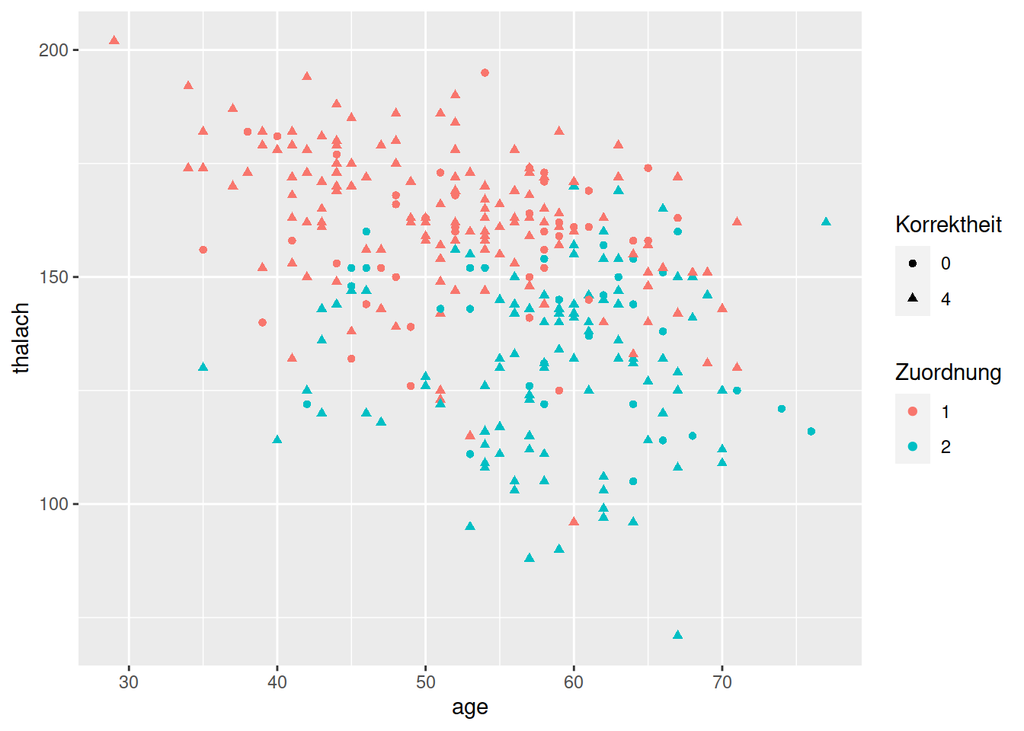

```r
# Ihre Lösung:
Zuordnung = factor(clustered_km$cluster)
Korrektheit = factor(result$difference * 4)
ggplot(df) +
  geom_point(aes(age, thalach, color = Zuordnung, shape = Korrektheit))
```

### Mit Dummy-Variablen

Nun sollen **alle Merkmale** benutzt werden.

#### Clustering

Clustern Sie diese Daten. Überlegen Sie, wie die Faktoren zu Zahlen werden.

```r
# Ihre Lösung:
df_transformed = fastDummies::dummy_columns(df) |> select_if(is.numeric)
df_all_scaled = scale(df_transformed)
clustered_all_km = stats::kmeans(df_all_scaled, centers = 2)
```

#### Richtig?

Berechnen Sie für diesen Fall, wie viel Prozent der Datensätze richtig einem Cluster eingeordnet wurden und geben Sie die Zahl auf zwei Nachkommastellen gerundet aus. Wie hat sich der Wert verändert? Warum ist dies so?

```r
# Ihre Lösung:
result_all = calculate_percentage_correct(df$goal, clustered_all_km$cluster)
result_all$percentage
```

```
## [1] 90.76
```

Der Wert ist deutlich höher als bei der vorherigen Zuweisung. Das leigt daran, dass jetzt mehr Merkmale verwendet werden konnten.

#### Scatterplot age vs. thalach

Plotten Sie erneut und schauen Sie, wie die richtigen Punkte nun verteilt sind. Die nun hinzugenommenen Merkmale scheinen also von Bedeutung für die Zuordnung zu sein und folglich vermutlich mit der Erkrankung zusammenzuhängen.

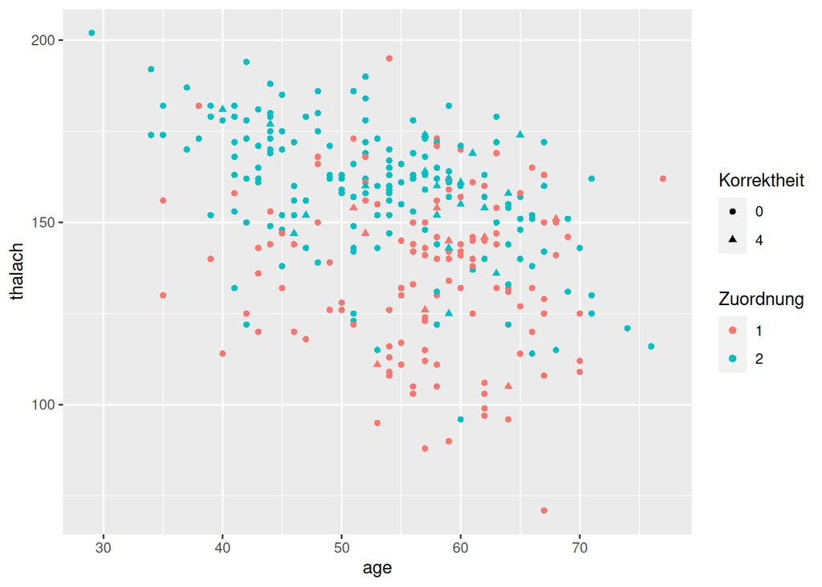

```r
# Ihre Lösung:
Zuordnung = factor(clustered_all_km$cluster)
Korrektheit = factor(result_all$difference * 4)
ggplot(df) +
  geom_point(aes(age, thalach, color = Zuordnung, shape = Korrektheit))
```

## PCA

Wenden Sie eine PCA auf diesen Datensatz an. Es sollen alle Merkmale berücksichtigt werden.

### Wichtige Merkmale

Welche Merkmale der ersten Hauptkomponente tragen am meisten zu der Varianz bei? Geben Sie die TOP 10 Merkmale an.

```r
# Ihre Lösung:
df_transformed_pca = fastDummies::dummy_columns(df) |> select_if(is.numeric)
pca = stats::prcomp(df_transformed_pca, scale = TRUE)
sort(abs(pca$rotation[,'PC1']), decreasing = TRUE)[1:10]
```

```
##    goal_0    thal_3    thal_7   oldpeak   thalach      ca_0     exang     slope
## 0.3771421 0.3360315 0.2997635 0.2734078 0.2659951 0.2634484 0.2526032 0.2263581
##        cp    goal_3
## 0.2171080 0.2037185
```

### Erste und zweite Hauptkomponente

Plotten Sie die erste und zweite Hauptkomponente als Scatterplot. Färben Sie die Punkte gemäß ihrer Klasse (Disease) ein.

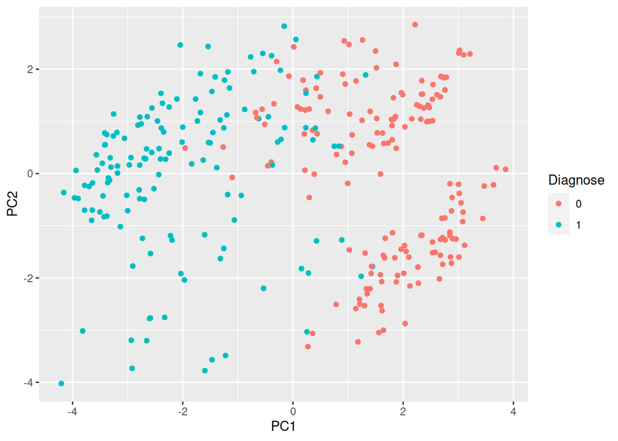

```r
# Ihre Lösung:
Diagnose = factor(sapply(df$goal, function(x) if (x == 0) 0 else 1))
ggplot(data.frame(pca$x)) +
  geom_point(aes(PC1, PC2, color = Diagnose))
```

### PVE

#### Plot

Plotten Sie die Proportion of Variance explained (PVE) für jede Hauptkomponente sowie die akkumulierte PVE.

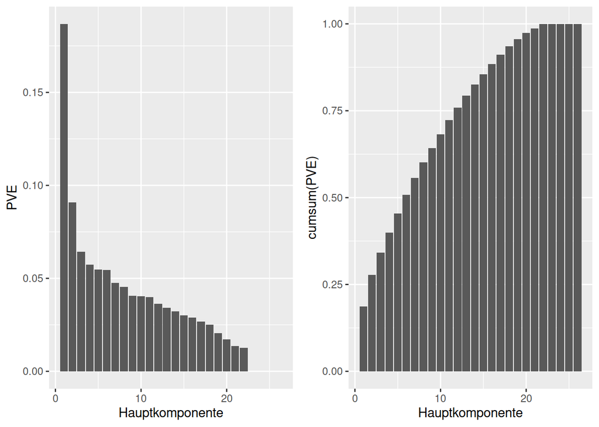

#### Wichtige Hauptkomponenten

Wie viele Hauptkomponenten erklären mehr als 50% der Varianz?

Möglicherweise tragen bei Ihrem Ergebnis die letzten Hauptkomponenten keine Varianz mehr bei. Überlegen Sie, woran das liegen könnte.

Das kann daran liegen, dass nicht alle Dimensionen zwangsweise mit der Klassifizierung zu tun haben. Dimensionen können auch unkorreliert sein.